# SIT744 Assignment 1: Image Classification with Deep Feedforward Neural Network

## Task 5 Overfitting and regularisation

*(weight ~30%)*

Go back to the previous task. Plot the training and validation loss and accuracy. Answer the following questions:

1. Do you see overfitting or underfitting? Why?
2. If you see overfitting, at which epoch did it happen?

Now retrain the model with only 200 training examples. (Make sure that you reinitialise the weights before retraining.) Do you see overfitting? How did the validation loss and accuracy change?

Neural networks are overparametrised models, meaning there can be more parameters than the training examples. Some form of regularisation is almost always necessary to obtain a useful model. Below are some options:

1. Add dropout
2. Add Batch Normalisation
3. Add layer-specific weight regularizations
4. Change the learning rate

In addition, you may also try changing the weight initialisation method.

Apply different regularisation techniques to the model training. You may also try other techniques for improving training such as learning rate scheduling (see https://www.tensorflow.org/guide/keras/train_and_evaluate#using_learning_rate_schedules).

Run **five or more** experiments of different training configurations and record the validation accuracy achieved in the Markdown table below. You may modify the table heading to match your experiment design.

| Dropout (rate) | Batch Normalisation (Y/N) | Optimiser | Learning Rate | Number of Epochs | Validation Accuracy |
| --- | --- | --- | --- | --- | --- |

Answer the following questions:

1. Which configuration achieved the best validation accuracy? Report the test accuracy of your final model.
2. Which setting had the most impact and which one had the least impact?

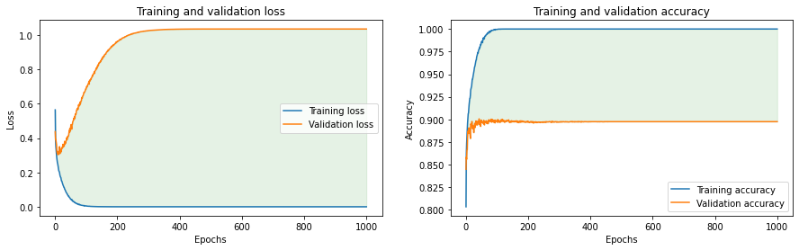

```python
# Plot training/validation accuracy and loss

import matplotlib.pyplot as plt

acc = history.history['accuracy']
val_acc = history.history['val_accuracy']
loss = history.history['loss']
val_loss = history.history['val_loss']
epochs = range(1, len(acc) + 1)

plt.figure(figsize=(15,4))

ax1 = plt.subplot(1, 2, 1)
plt.plot(epochs, loss, label='Training loss')
plt.plot(epochs, val_loss, label='Validation loss')
plt.fill_between(epochs, loss,val_loss,color='g',alpha=.1)

plt.title('Training and validation loss')
plt.xlabel('Epochs')
plt.ylabel('Loss')
plt.legend()

ax2 = plt.subplot(1, 2, 2)
plt.plot(epochs, acc, label='Training accuracy')
plt.plot(epochs, val_acc, label='Validation accuracy')
plt.fill_between(epochs, acc,val_acc,color='g',alpha=.1)
plt.title('Training and validation accuracy')
plt.xlabel('Epochs')
plt.ylabel('Accuracy')
plt.legend()
plt.show()
```

Question1&2 The model could be overfitting because the accuracy and loss flucation in the begining which is the epoch between 0 and 200.

```python
# Training model with 200 samples.

# Download dataset to split Training and Testing set
fashion = keras.datasets.fashion_mnist
train, (x_test, y_test) = fashion.load_data()

x_train, y_train = train

x_train = x_train/255
x_test = x_test/255

# Split 200 from dataset for training
train_count = -200
val_count = -50

x_train200 = x_train[train_count:]
y_train200 = y_train[train_count:]
x_val200 = x_train200[val_count:]
y_val200 = y_train200[val_count:]
```

```python
# Model Construction

model_200 = keras.Sequential([
    keras.layers.Flatten(input_shape=(28, 28)),
    keras.layers.Dense(256, activation='relu'),
    keras.layers.Dense(128, activation='relu'),
    keras.layers.Dense(10)
])

# learning rate schedule
initial_learning_rate = 1e-3
lr_schedule = keras.optimizers.schedules.ExponentialDecay(
    initial_learning_rate, decay_steps=1000, decay_rate=0.9, staircase=True
)

ADAM = Adam(learning_rate=lr_schedule)

# Model Compile
model_200.compile(optimizer = ADAM,
              loss=tf.keras.losses.SparseCategoricalCrossentropy(from_logits=True),
              metrics=['accuracy'])
```

```python
# Training model

epoch_num = 1000
batch_size = 256

history_200 = model_200.fit(x_train200, y_train200,
                    epochs=epoch_num,
                    batch_size = batch_size,
                    validation_data = (x_val200, y_val200))
```

```python
# Evaluate the model on the test data using `evaluate`
print("Evaluate on test data")
results = model_200.evaluate(x_test, y_test, batch_size=256)
print("test loss, test acc:", results)
```

```
Evaluate on test data
test loss, test acc: [1.8341736793518066, 0.7416999936103821]
```

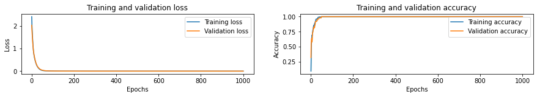

```python
# Plot training/validation accuracy and loss

import matplotlib.pyplot as plt

acc = history_200.history['accuracy']
val_acc = history_200.history['val_accuracy']
loss = history_200.history['loss']
val_loss = history_200.history['val_loss']
epochs = range(1, len(acc) + 1)

plt.figure(figsize=(15,4))

ax1 = plt.subplot(221)
plt.plot(epochs, loss, label='Training loss')
plt.plot(epochs, val_loss, label='Validation loss')
plt.fill_between(epochs, loss,val_loss,color='g',alpha=.1)

plt.title('Training and validation loss')
plt.xlabel('Epochs')
plt.ylabel('Loss')
plt.legend()

ax2 = plt.subplot(222)
plt.plot(epochs, acc, label='Training accuracy')
plt.plot(epochs, val_acc, label='Validation accuracy')
plt.fill_between(epochs, acc,val_acc,color='g',alpha=.1)
plt.title('Training and validation accuracy')
plt.xlabel('Epochs')
plt.ylabel('Accuracy')
plt.legend()
plt.show()
```

```python
# Split data for training and validation

# Download dataset to split Training and Testing set
fashion = keras.datasets.fashion_mnist
train, (x_test, y_test) = fashion.load_data()

x_train, y_train = train

x_train = x_train/255
x_test = x_test/255

# Split 8000 validation dataset from testing data set
val_count = -8000

#Validation data
x_val = x_train[val_count:]
y_val = y_train[val_count:]
# Training data
x_train = x_train[:val_count]
y_train = y_train[:val_count]
```

```
Downloading data from https://storage.googleapis.com/tensorflow/tf-keras-datasets/train-labels-idx1-ubyte.gz
Downloading data from https://storage.googleapis.com/tensorflow/tf-keras-datasets/train-images-idx3-ubyte.gz
Downloading data from https://storage.googleapis.com/tensorflow/tf-keras-datasets/t10k-labels-idx1-ubyte.gz
Downloading data from https://storage.googleapis.com/tensorflow/tf-keras-datasets/t10k-images-idx3-ubyte.gz
```

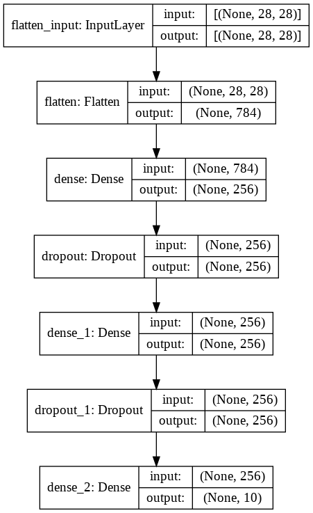

```python
# Import package
from keras.layers import Dropout

# Create model with drop out
dropout = keras.Sequential()
dropout.add(keras.layers.Flatten(input_shape=(28, 28)))

dropout.add(keras.layers.Dense(256, activation='relu'))
dropout.add(Dropout(0.50))  # Add drop out

dropout.add(keras.layers.Dense(256, activation='relu'))
dropout.add(Dropout(0.50))  # Add drop out

dropout.add(keras.layers.Dense(10, activation='softmax'))



# Model Compile
dropout.compile(optimizer = 'adam',
              loss=tf.keras.losses\
              .SparseCategoricalCrossentropy(
             from_logits=True
            ),
              metrics=['accuracy']
    )

# Visulize Model
plot_model(dropout, show_shapes=True)
```

```python
# Training Dropout Model
epoch_num = 100
batch_size = 128

history_dropout = dropout.fit(x_train, y_train,
                    epochs = epoch_num,
                    batch_size = batch_size,
                    validation_data = (x_val, y_val))
```